# Oxford Happiness Questionnaire

coop711

2025-02-09 22:05:56

# 옥스포드 행복도 조사 집계

## 실험의 목적

옥스포드 행복 설문지 실험결과를 분석합니다.

이 실험에는 두 가지 목적이 있습니다.

첫째는 있는 그대로 옥스포드 행복 설문지로 측정하는 여러분의 행복 수준은 어느 정도인지,

둘째는 영문판으로 응답할 때와 국문판으로 응답할 때 어떤 차이가 있는지, 특히 응답에 소요되는 시간을 측정해서 비교해 보았습니다.

### Red, Black을 잘못 표시한 사람들

|  | Red(옥스포드행복설문지) | Black(옥스포드행복설문지) |
| --- | --- | --- |
| **Red(랜덤화출석부)** | 361 | 2 |
| **Black(랜덤화출석부)** | 4 | 370 |
| **계** | 365 | 372 |

랜덤화출석부에 있는 Red, Black 과 실제 구글설문에 올린 Red, Black 이 다른 사람들의 수효는 6명입니다.

Red를 Black 이라고 한 사람이 2명, Black 을 Red 라고 한 사람이 4명입니다.

### 응답인원의 Red, Black

Red(국문) 로 응답한 인원은 365명, Black(영문) 에 응답한 인원은 372명입니다.

전체 응답인원 737 명을 랜덤하게 둘로 나눌 때 어느 한 쪽의 기대인원은 이를 반으로 나눠 준 368.5명이고, 표준오차는 이의 제곱근에 1/2을 곱해 준 13.6 명입니다.

따라서 Red, Black 각 그룹에 관찰된 인원은 기대인원으로부터 표준오차 범위 안에 들어갑니다.

## 행복 점수 비교

국문 설문지와 영문 설문지의 행복점수를 비교합니다.

먼저 기초통계입니다.

행복점수 단계별로 비교했을 때나 기초통계로 비교했을 때나 국문 설문지로 작성한 그룹 (Red)의 행복점수가 높게 나옵니다.

그 차이는 통계적으로 유의한 수준입니다.

### `summary()`

- **국문**:

  | Min. | 1st Qu. | Median | Mean | 3rd Qu. | Max. |
  | --- | --- | --- | --- | --- | --- |
  | 1.345 | 3.483 | 4 | 4.035 | 4.552 | 5.655 |

- **영문**:

  | Min. | 1st Qu. | Median | Mean | 3rd Qu. | Max. |
  | --- | --- | --- | --- | --- | --- |
  | 1.793 | 3.448 | 3.707 | 3.855 | 4.207 | 5.655 |

Red(국문) 집단의 평균 행복점수는 4.04, Black(영문) 집단의 평균 행복점수는 3.86 으로 국문 설문지에 응답한 행복점수의 평균이 0.18점 더 높게 나옵니다.

중위수를 비교하더라도 Red(국문) 집단의 행복점수 중위수는 4.00, Black(영문) 집단의 행복점수 중위수는 3.71 으로 국문 설문지에 응답한 행복점수의 중위수가 0.29 점 더 높게 나옵니다.

### `t.test()` on means

Welch Two Sample t-test: `Scores` by `group`

| Test statistic | df | P value | Alternative hypothesis | mean in group 국문 | mean in group 영문 |
| --- | --- | --- | --- | --- | --- |
| 3.695 | 693.6 | 0.000237 * * * | two.sided | 4.035 | 3.855 |

국문 설문지에 대한 행복점수의 평균과 영문 설문지에 대한 행복점수의 평균에서 관찰된 차이가 통계적으로 유의한지 t-test 로 알아 봅니다.

양 집단의 표준편차를 알 수 없기 때문에 Welch 의 근사식을 활용합니다.

이 때 t-통계량은 3.70, 자유도는 693.62, p-value 는 0.00024라고 나옵니다.

즉, 통계적으로 유의한 차이를 관찰하였습니다.

국문 행복도 조사지와 영문 행복도 조사지의 행복점수에는 차이가 있고, 국문 행복도의 평균점수가 더 높은 것으로 나왔습니다.

결과 요약표에는 각 집단의 평균 행복점수도 나와 있습니다.

국문으로 물어 봤을 때하고 영문으로 물어 봤을 때는 명확히 차이가 있다는 것을 알 수 있습니다.

왜 그런 차이가 관찰되는 걸까요?

### `table()`

|  | 행복하지 않다 | 다소 행복하지 않다 | 그저 그렇다 | 꽤 행복하다 | 매우 행복하다 | 계 |
| --- | --- | --- | --- | --- | --- | --- |
| **국문** | 2 | 15 | 165 | 142 | 41 | 365 |
| **영문** | 1 | 12 | 228 | 113 | 18 | 372 |
| **계** | 3 | 27 | 393 | 255 | 59 | 737 |

이번에는 국문 행복도 조사 결과와 영문 행복도 조사 결과를 등급별로 나누어 교차표를 계산해 보았습니다.

국문, 영문의 차이는 어떤가요?

### `chisq.test()`

Pearson’s Chi-squared test with simulated p-value (based on 2000 replicates): `.`

| Test statistic | df | P value |
| --- | --- | --- |
| 22.61 | NA | 0.0004998 * * * |

국문, 영문 행복도 조사 결과의 등급별 차이를 파악하기 위하여 카이제곱 테스트를 수행하였습니다.

그 결과 카이제곱 통계량은 22.61, 반복수 2,0000의 붓스트랩 근사를 사용하였기 때문에 자유도는 알 수 없고, p-value 는 5e-04이므로 통계적으로 유의한 차이를 보입니다.

### 백분율(%)

| 행복하지 않다 | 다소 행복하지 않다 | 그저 그렇다 | 꽤 행복하다 | 매우 행복하다 | 계 |
| --- | --- | --- | --- | --- | --- |
| 0.4 | 3.7 | 53.3 | 34.6 | 8.0 | 100.0 |

행복점수의 등급별 백분율을 파악해 보면 꽤 행복하다 이상이 42.61%이고, 그저 그렇다가 53.32%, 다소 행복하지 않다 이하가 4.07 입니다.

### `geom_boxplot()`

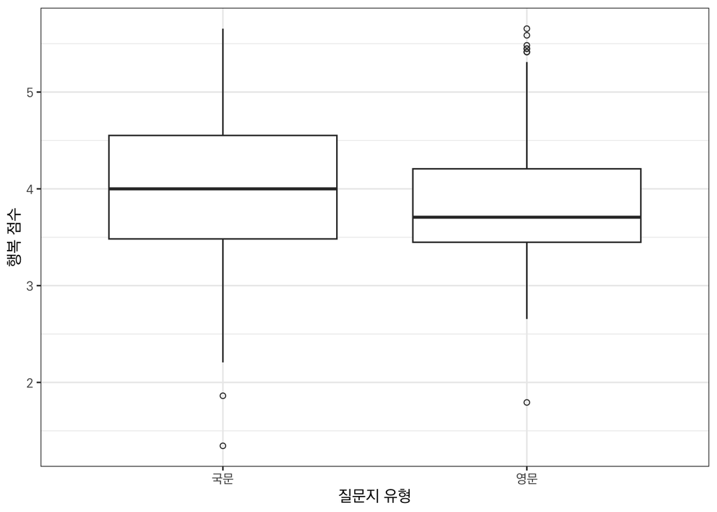

국문, 영문 행복도 조사 결과를 시각적으로 비교하기 위하여 Boxplot 을 그려 보았습니다.

국문 행복도 조사의 중위수가 영문 행복도 조사의 중위수보다 높다는 게 눈에 띕니다.

그 밖에 기초 통계에 나오는 통계값들을 시각적으로 비교할 수 있습니다.

## 소요시간 비교

초 단위로 측정한 소요시간에서는 오전, 오후를 잘못 쓴다거나 시작 시간을 제출 시간보다 늦게 입력한 사람들도 있고, 과도하게 (한 시간 이상) 소요된 것으로 나오는 사람들이 있어서 일일이 찾아서 수정하였고, 한 시간 이상은 사실상 설문지를 작성하다가 다른 일을 하고 다시 돌아와 마치는 것으로 판단하여 NA 로 처리하였습니다.

기초 통계부터 살펴보겠습니다.

### `summary()`

- **국문**:

  | Min. | 1st Qu. | Median | Mean | 3rd Qu. | Max. | NA’s |
  | --- | --- | --- | --- | --- | --- | --- |
  | 1 | 141 | 184 | 286.7 | 280 | 2907 | 32 |

- **영문**:

  | Min. | 1st Qu. | Median | Mean | 3rd Qu. | Max. | NA’s |
  | --- | --- | --- | --- | --- | --- | --- |
  | 18 | 111.5 | 218 | 353.1 | 394.2 | 3564 | 32 |

국문 행복도 조사의 평균 소요시간은 286.71초, 영문 행복도 조사의 평균 소요시간은 353.08초이므로 평균적으로 66.4초, 즉 1분 6초 정도 국문 행복도 조사 시간이 덜 걸립니다.

소요시간의 중위수를 비교해 보아도 국문 행복도 조사 소요시간의 중위수는 184.00초, 영문 행복도 조사 소요시간의 중위수는 218.00초이므로 34 초, 약 0분 34초 만큼 국문 행복도 조사의 소요시간이 덜 걸립니다.

### `geom_boxplot()`

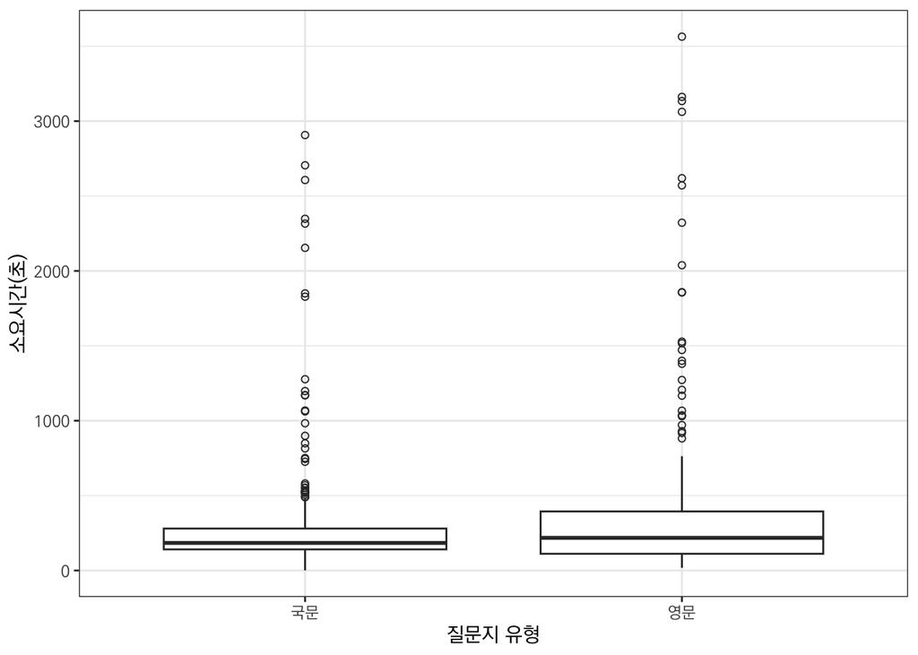

국문, 영문 행복도 조사 소요시간의 Boxplot 을 그려 보았습니다.

워낙 큰 값들이 많이 나오기 때문에 중위수 비교 등이 좀 어려운 측면이 있습니다.

### `t.test()` on means

Welch Two Sample t-test: `as.numeric(Duration)` by `group`

| Test statistic | df | P value | Alternative hypothesis | mean in group 국문 | mean in group 영문 |
| --- | --- | --- | --- | --- | --- |
| -1.996 | 641 | 0.04632 * | two.sided | 286.7 | 353.1 |

국문, 영문 행복도 조사의 소요 시간에 대해서도 t-test 를 수행하였는데 t-통계량은 -2.00, 자유도는 640.95, p-value 는 0.046이어서 통계적으로 유의한 차이가 관찰되고 있습니다.

## 마감 시간으로부터 제출 시간의 분포

### 분포표

일 단위

|  | [0,1] | (1,2] | (2,3] | (3,4] | (4,5] | (5,6] | (6,7] | (7,8] | (8,9] | (9,10] | (10,11] | (11,12] | (12,13] | (13,14] | 계 |
| --- | --- | --- | --- | --- | --- | --- | --- | --- | --- | --- | --- | --- | --- | --- | --- |
| **국문** | 116 | 27 | 8 | 13 | 12 | 13 | 15 | 46 | 29 | 16 | 21 | 13 | 15 | 21 | 365 |
| **영문** | 116 | 21 | 18 | 10 | 7 | 7 | 13 | 56 | 37 | 19 | 19 | 13 | 14 | 22 | 372 |
| **계** | 232 | 48 | 26 | 23 | 19 | 20 | 28 | 102 | 66 | 35 | 40 | 26 | 29 | 43 | 737 |

분포표로부터 두 가지 문제를 살펴보겠습니다.

첫째, 날마다 고르게 제출하는가?

둘째, Red(국문), Black(영문) 간에 통계적으로 유의한 차이가 있는가?

각 문제를 살펴보기 위해서는 분포표의 일부분을 대상으로 카이제곱 테스트를 수행합니다.

### 날마다 고르게 제출하는가?

| [0,1] | (1,2] | (2,3] | (3,4] | (4,5] | (5,6] | (6,7] | (7,8] | (8,9] | (9,10] | (10,11] | (11,12] | (12,13] | (13,14] |
| --- | --- | --- | --- | --- | --- | --- | --- | --- | --- | --- | --- | --- | --- |
| 232 | 48 | 26 | 23 | 19 | 20 | 28 | 102 | 66 | 35 | 40 | 26 | 29 | 43 |

Chi-squared test for given probabilities: `.`

| Test statistic | df | P value |
| --- | --- | --- |
| 779.4 | 13 | 3.514e-158 * * * |

날마다 고르게 제출하는지 알아 보았습니다.

분포표의 “계”행에서 ’계’열을 제외하고 카이제곱테스트를 수행합니다.

분포표 만으로도 쉽게 파악할 수 있지만 카이제곱테스트가 명확히 해 줍니다.

카이제곱 통계량은 779.43, 자유도는 13.00, p-value 는 3.5e-158 이므로 제출은 고르지 않고 특정 날짜에 치우쳐 있습니다.

막대그래프로 살펴 보겠습니다.

### 막대그래프

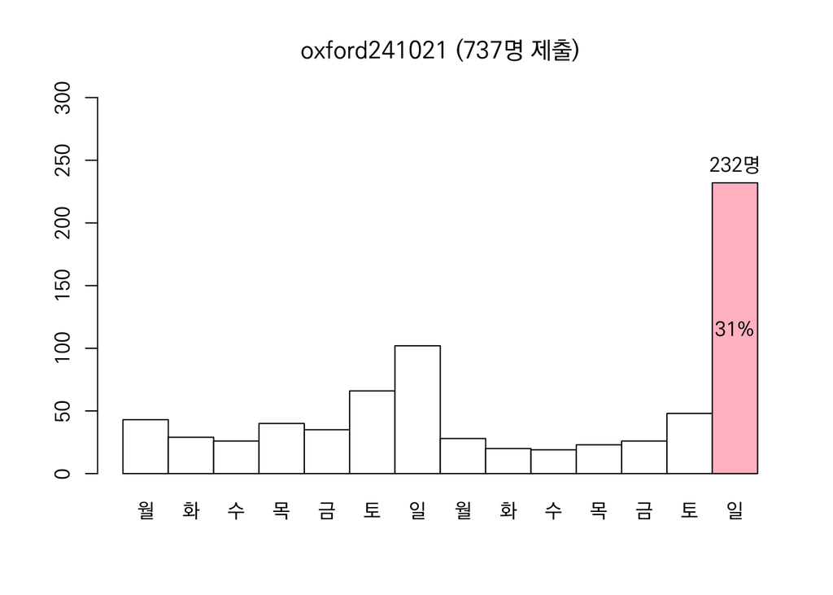

### Red(국문), Black(영문) 간에 닮았는가?

|  | [0,1] | (1,2] | (2,3] | (3,4] | (4,5] | (5,6] | (6,7] | (7,8] | (8,9] | (9,10] | (10,11] | (11,12] | (12,13] | (13,14] |
| --- | --- | --- | --- | --- | --- | --- | --- | --- | --- | --- | --- | --- | --- | --- |
| **국문** | 116 | 27 | 8 | 13 | 12 | 13 | 15 | 46 | 29 | 16 | 21 | 13 | 15 | 21 |
| **영문** | 116 | 21 | 18 | 10 | 7 | 7 | 13 | 56 | 37 | 19 | 19 | 13 | 14 | 22 |

Pearson’s Chi-squared test: `.`

| Test statistic | df | P value |
| --- | --- | --- |
| 10.55 | 13 | 0.6488 |

제출시간의 분포가 Red(국문), Black(영문) 간에 닮았는지 알아 보았습니다.

이번에는 분포표의 첫번쨰와 두번쨰 행, ’계’열을 제외한 나머지 열에 대해서 카이제곱테스트를 수행합니다.

카이제곱 통계량은 10.55, 자유도는 13, p-value 는 0.65 이므로 제출 시간의 분포는 Red(국문), Black(영문) 간에 통계적으로 유의한 차이가 관찰되지 않습니다.

이 사실을 Mosaic Plot 을 이용하여 시각적으로 살펴보겠습니다. 닮았다고 느껴지나요?

### Mosaic Plot

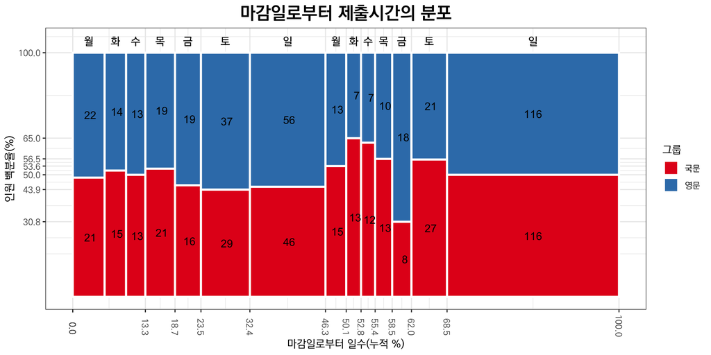